# Chapter 1 Introduction

# Preview

- What is international economics about?
- International trade topics
  - Gains from trade, explaining patterns of trade, effects of government policies on trade.
- International finance topics
  - Balance of payments, exchange rate determination, international policy coordination and capital markets.
- International trade versus finance

# What Is International Economics About?

# What Is International Economics About?

- International economics is about how nations interact through:
  - trade of goods and services, flows of money, and investment.
- International economics is an old subject, but continues to grow in importance as countries become tied more to the international economy.
- Nations are now more closely linked than ever before.

# What Is International Economics About?

- International trade as a fraction of the national economy has tripled for the U.S. in the past 40 years.
  - Both imports and exports fell in 2009.
- Compared to the U.S., other countries are even more tied to international trade.

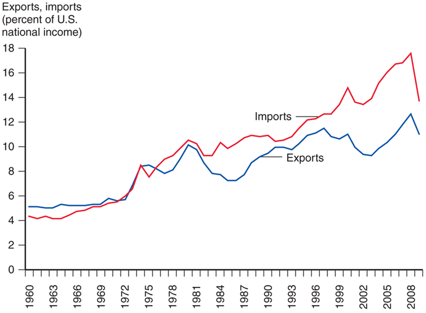

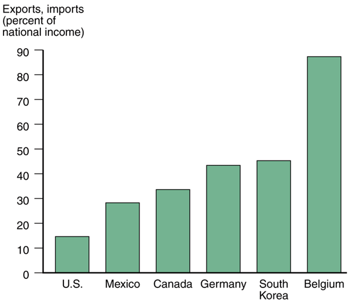

# Gains from Trade

- Several ideas underlie the gains from trade.
  1. When a buyer and a seller engage in a voluntary transaction, both can be made better off.
     - Norwegian consumers import oranges that they would have a hard time producing.
     - The producer of the oranges receives income that it can use to buy other things that it desires.

# Gains from Trade

2. How could a country that is the most (least) efficient producer of everything gain from trade?
   - Countries use finite resources to produce what they are most productive at (compared to their other production choices), then trade those products for goods and services that they want to consume.
   - Countries can specialize in production, while consuming many goods and services through trade.

# Gains from Trade

3. Trade benefits countries by allowing them to export goods made with relatively abundant resources and imports goods made with relatively scarce resources.
4. When countries specialize, they may be more efficient due to larger-scale production.
5. Countries may also gain by trading current resources for future resources (international borrowing and lending) and due to international migration.

# Gains from Trade

- Trade is predicted to benefit countries as a *whole* in several ways, but trade may harm *particular groups within a country*.
  - International trade can harm the owners of resources that are used relatively intensively in industries that compete with imports.
  - Trade may therefore affect the distribution of income within a country.

# Patterns of Trade

- Differences in *climate and resources* can explain why Brazil exports coffee and Australia exports iron ore.
- But why does Japan export automobiles, while the U.S. exports aircraft?
- Why some countries export certain products can stem from differences in:
  - Labor productivity
  - Relative supplies of capital, labor and land and their use in the production of different goods and services

# Effects of Government Policies on Trade

- Policy makers affect the amount of trade through
  - *tariffs*: a tax on imports or exports,
  - *quotas*: a quantity restriction on imports or exports,
  - *export subsidies*: a payment to producers that export,
  - or through other regulations (ex., product specifications) that exclude foreign products from the market, but still allow domestic products.
- What are the costs and benefits of these policies?

# Effects of Government Policies on Trade

- If a government must restrict trade, which policy should it use and *how much* should it restrict trade?
- If a government restricts trade, what are the costs if foreign governments respond likewise?
- Trade policies are often chosen to cater to special interest groups, rather than to maximize national welfare.
- Governments tend to adopt tariffs, then negotiate them down in exchange for reduction in trade barriers of other countries.

# International Finance Topics

- Exchanging risky assets such as stocks and bonds can benefit all countries by diversification that reduces the variability of income – another source of gains from trade.
- Most international trade involves monetary transactions.
- Many monetary events have important consequences for international trade.

# Balance of Payments

- Governments measure the value of exports and imports, as well as the value of financial assets that flow into and out of their countries.
  - Trade deficits, where countries import more than they export in value, may be offset by net inflows of financial assets.
- The *official settlements balance*, or the balance of payments, measures the balance of funds that central banks use for official international payments.
- All three values are measured in the government’s *national income accounts*.

# Exchange Rate Determination

- *Exchange rates* are an important financial issue for most governments.
- Exchange rates measure how much domestic currency can be exchanged for foreign currency and thus affect:
  - how much goods denominated in foreign currency (imports) cost in the domestic country.
  - how much goods denominated in domestic currency (exports) cost in foreign markets.
- Some exchange rates change continually (float) while others are fixed for periods of time.

# International Policy Coordination

- In an integrated economy, one country’s economic policies usually affect other countries as well, leading to the need for some degree of policy coordination.
  - Depends on type of exchange rate regime.
- Capital markets, where money is exchanged for promises to pay in the future, have special concerns in an international setting:
  - Currency fluctuations can alter the value paid.
  - Countries, especially developing ones, might default on debt.

# International Economics: Trade and Money

# International Trade Versus Finance

- International trade focuses on transactions involving movement of goods and services across nations.
  - International trade theory (chapters 2–8) and policy (chapters 9–12)
- International finance focuses on financial or monetary transactions across nations.
  - International monetary theory (chapters 13–18) and policy (chapters 19–22)